# Iris Dataset Classification(Analysis)

## IRIS Dataset Information

The data set contains 3 classes of 50 instances each , where each class refers to a type of Iris Plant. 1; class is linearly separable from the other 2; the latter are NOT linearly separable from each other. Attribute Information: 1. Sepal length in cm 2. Sepal width in cm 3. Petal length in cm 4. Petal width in cm 5. Class:- Iris Setosa Iris Versicolour Iris Virginica Here we have 4 Input Attributes with 1 output Attribute i.e. Class. So, I will predict the output class based on the 4 -Input Attributes.

## Import Modules

```python
import pandas as pd
import numpy as np
import os
import matplotlib as plt
import seaborn as sns
```

## Loading the Dataset

```python
df= pd.read_csv('D:/Iris.csv')
```

```python
#Display 1st 5 rows from Dataset
df.head()
```

|  | Id | SepalLengthCm | SepalWidthCm | PetalLengthCm | PetalWidthCm | Species |
| --- | --- | --- | --- | --- | --- | --- |
| 0 | 1 | 5.1 | 3.5 | 1.4 | 0.2 | Iris-setosa |
| 1 | 2 | 4.9 | 3.0 | 1.4 | 0.2 | Iris-setosa |
| 2 | 3 | 4.7 | 3.2 | 1.3 | 0.2 | Iris-setosa |
| 3 | 4 | 4.6 | 3.1 | 1.5 | 0.2 | Iris-setosa |
| 4 | 5 | 5.0 | 3.6 | 1.4 | 0.2 | Iris-setosa |

```python
# delete a Column
df=df.drop(columns=['Id'],axis=1)
```

```python
df.head()
```

|  | SepalLengthCm | SepalWidthCm | PetalLengthCm | PetalWidthCm | Species |
| --- | --- | --- | --- | --- | --- |
| 0 | 5.1 | 3.5 | 1.4 | 0.2 | Iris-setosa |
| 1 | 4.9 | 3.0 | 1.4 | 0.2 | Iris-setosa |
| 2 | 4.7 | 3.2 | 1.3 | 0.2 | Iris-setosa |
| 3 | 4.6 | 3.1 | 1.5 | 0.2 | Iris-setosa |
| 4 | 5.0 | 3.6 | 1.4 | 0.2 | Iris-setosa |

```python
df.describe()                         # Stats about the Data
```

|  | SepalLengthCm | SepalWidthCm | PetalLengthCm | PetalWidthCm |
| --- | --- | --- | --- | --- |
| count | 150.000000 | 150.000000 | 150.000000 | 150.000000 |
| mean | 5.843333 | 3.054000 | 3.758667 | 1.198667 |
| std | 0.828066 | 0.433594 | 1.764420 | 0.763161 |
| min | 4.300000 | 2.000000 | 1.000000 | 0.100000 |
| 25% | 5.100000 | 2.800000 | 1.600000 | 0.300000 |
| 50% | 5.800000 | 3.000000 | 4.350000 | 1.300000 |
| 75% | 6.400000 | 3.300000 | 5.100000 | 1.800000 |
| max | 7.900000 | 4.400000 | 6.900000 | 2.500000 |

```python
df.info()                           # Basic info of Datatype
```

```
<class 'pandas.core.frame.DataFrame'>
RangeIndex: 150 entries, 0 to 149
Data columns (total 5 columns):
 #   Column         Non-Null Count  Dtype
---  ------         --------------  -----
 0   SepalLengthCm  150 non-null    float64
 1   SepalWidthCm   150 non-null    float64
 2   PetalLengthCm  150 non-null    float64
 3   PetalWidthCm   150 non-null    float64
 4   Species        150 non-null    object
dtypes: float64(4), object(1)
memory usage: 6.0+ KB
```

```python
df['Species'].value_counts()         #Displaying Number of Sample in each Class
```

```
Iris-setosa        50
Iris-versicolor    50
Iris-virginica     50
Name: Species, dtype: int64
```

## Preprocessing the Dataset

```python
df.isnull().sum()                   # Check for Null Values
```

```
SepalLengthCm    0
SepalWidthCm     0
PetalLengthCm    0
PetalWidthCm     0
Species          0
dtype: int64
```

## Exploratory Data Analysis

```python
# HISTOGRAMS
```

Here we will visualize the Data in the form of Graph. For each column I will plot the Histogram.

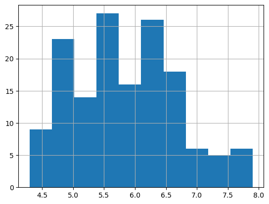

```python
df['SepalLengthCm'].hist()
```

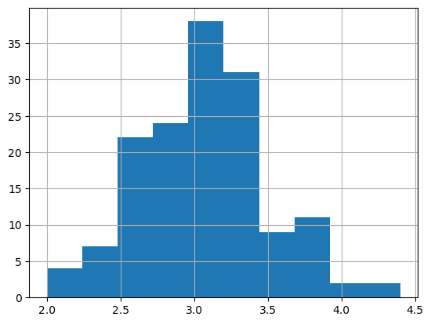

```python
df['SepalWidthCm'].hist()
```

Here In this Graph we have a NORMAL DISTRIBUTION & If all the Columns are in the Normal Distribution then, it means that the MODEL can quickly learn from the Data, Because it is in the form of ND. So, that's why we always need to prefferd the data in the form of ND.

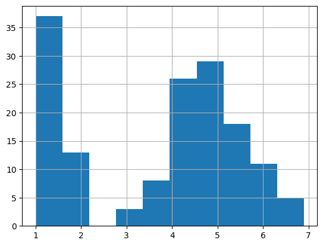

```python
df['PetalLengthCm'].hist()
```

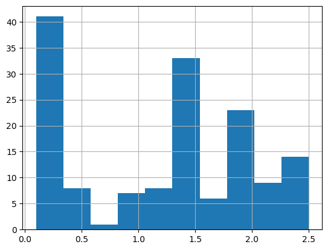

```python
df['PetalWidthCm'].hist()
```

# SCATTER PLOT I am going to plot the points for each class & we are going to colour for each class.

```python
import matplotlib.pyplot as plt                                         # To add the 'scatter' attribute in Matplotlib
```

```python
colors=['red','orange','blue']
species= ['Iris-setosa', 'Iris-versicolor' ,'Iris-virginica']           # Define the colors and Classes
```

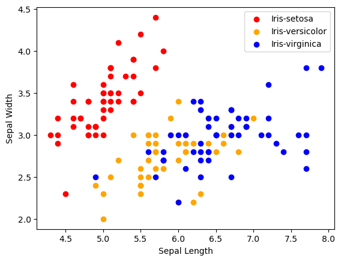

```python
for i in range(3):
    x = df[df['Species']== species[i]]
    plt.scatter (x['SepalLengthCm'], x['SepalWidthCm'], c = colors[i], label=species[i])

plt.xlabel("Sepal Length")
plt.ylabel("Sepal Width")
plt.legend()
```

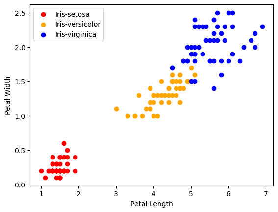

```python
for i in range(3):
    x = df[df['Species']== species[i]]
    plt.scatter (x['PetalLengthCm'], x['PetalWidthCm'], c = colors[i], label=species[i])

plt.xlabel("Petal Length")
plt.ylabel("Petal Width")
plt.legend()
```

This graph is very much likely to separate. So, I can consider,These 2-Attribute as the Best Attributes Because we can separate the classes easily by Visualizing these.

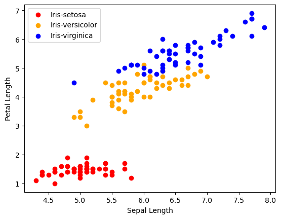

```python
for i in range(3):
    x = df[df['Species']== species[i]]
    plt.scatter (x['SepalLengthCm'], x['PetalLengthCm'], c = colors[i], label=species[i])

plt.xlabel("Sepal Length")
plt.ylabel("Petal Length")
plt.legend()
```

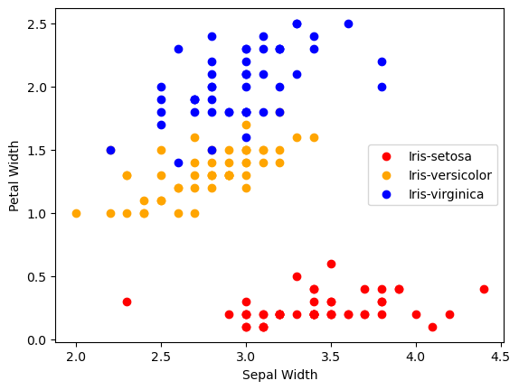

```python
for i in range(3):
    x = df[df['Species']== species[i]]
    plt.scatter (x['SepalWidthCm'], x['PetalWidthCm'], c = colors[i], label=species[i])

plt.xlabel("Sepal Width")
plt.ylabel("Petal Width")
plt.legend()
```

These are Some Visualization Techniques.

## Coorelation Matrix

1. coorelation matrix is a table showing correlation between variables. 2. Each cell in the table shows the correlation between two Variables. 3. The Value is in range of -1 to 1. 4. If 2 variables have high correlation , then we can neglect 1-variable from those two.

```python
df.corr()
```

|  | SepalLengthCm | SepalWidthCm | PetalLengthCm | PetalWidthCm |
| --- | --- | --- | --- | --- |
| SepalLengthCm | 1.000000 | -0.109369 | 0.871754 | 0.817954 |
| SepalWidthCm | -0.109369 | 1.000000 | -0.420516 | -0.356544 |
| PetalLengthCm | 0.871754 | -0.420516 | 1.000000 | 0.962757 |
| PetalWidthCm | 0.817954 | -0.356544 | 0.962757 | 1.000000 |

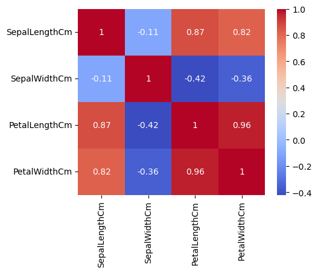

```python
corr = df.corr()                         # showing this matrix in the form of MAP
fig, ax = plt.subplots(figsize=(5,4))
sns.heatmap(corr, annot=True, ax=ax,cmap= 'coolwarm')
```

## Label Encoder

1. In Machine Learning, we usually deal with data sets which contains mutiple labels in 1 or more than 1-Columns. 2. These labels can be in the form of words or numbers. 3. Label Encoding refers to converting the labels into numeric form so as to convert it into the machine readable form.

```python
from sklearn import preprocessing
```

```python
le=preprocessing.LabelEncoder()
```

```python
df['Species'] = le.fit_transform(df['Species'])
```

```python
df.head()
```

|  | SepalLengthCm | SepalWidthCm | PetalLengthCm | PetalWidthCm | Species |
| --- | --- | --- | --- | --- | --- |
| 0 | 5.1 | 3.5 | 1.4 | 0.2 | 0 |
| 1 | 4.9 | 3.0 | 1.4 | 0.2 | 0 |
| 2 | 4.7 | 3.2 | 1.3 | 0.2 | 0 |
| 3 | 4.6 | 3.1 | 1.5 | 0.2 | 0 |
| 4 | 5.0 | 3.6 | 1.4 | 0.2 | 0 |

So, here all the String Variables of 'Species' is Converted to Numeric. Hence it is one of the important Preprocessing Technique.

## Model Training

After doing all the Analysis or Classification & the preprocessing in the Dataset I will go for the training. Before training the model we need a trained data and test data to Validate.

```python
from sklearn.model_selection import train_test_split
```

```python
# Split the Data for Training & Testing.
#train - 70
#test - 30

X= df.drop(columns=['Species'],axis=1)
Y= df['Species']
```

```python
x_train, x_test, y_train , y_test = train_test_split(X, Y, test_size=0.30)
```

```python
# LOGISTIC REGRESSION

from sklearn.linear_model import LogisticRegression
model = LogisticRegression()
```

```python
# Model Training

model.fit(x_train, y_train)
```

```
LogisticRegression()
```

```python
# Print Metric to Get Performance

print("Accuracy: ",model.score(x_test,y_test) * 100)
```

```
Accuracy:  95.55555555555556
```

So, the ACCURACY is 95 % for LOGISTIC REGRESSION.

```python
# KNN - K-NEAREST NEIGHBOURS
```

```python
from sklearn.neighbors import KNeighborsClassifier
model= KNeighborsClassifier()
```

```python
model.fit(x_train, y_train)
```

```
KNeighborsClassifier()
```

```python
# Print Metric to Get Performance

print("Accuracy: ",model.score(x_test,y_test) * 100)
```

```
Accuracy:  100.0
```

```python
# DECISION TREE
from sklearn.tree import DecisionTreeClassifier
model= DecisionTreeClassifier()
```

```python
model.fit(x_train,y_train)
```

```
DecisionTreeClassifier()
```

```python
# Print Metric to Get Performance

print("Accuracy: ",model.score(x_test,y_test) * 100)
```

```
Accuracy:  93.33333333333333
```